# Airbnb Amsterdam

## Introduction

### Data

The data can be found [here](http://insideairbnb.com/get-the-data.html). We will be using these data files:

- *detailed_listings:* Detailed listings for Amsterdam.
- *calenar:* Detailed calendar data for listings in Amsterdam.
- *listings:* Summarized listings information for Amsterdam.

**CRISP-DM (Cross-Industry Standard Process for Data Mining) consists of:**

- Business Understanding
- Data Understanding
- Data Preparation/ Wrangling
- Data Modeling
- Data Evaluation
- Deployment

## Understanding of Data

### To Find Out:

- *Most expensive month to visit amsterdam?*
- *What are the attributes associated with the price of a listing?*
- *Most expensive and least expensive Neighbourhood in Amsterdam?*
- *Is it more expensive to book a listing during the high seasons.*

```python
# importing ibraries
import pandas as pd
import numpy as np
import matplotlib.pyplot as plt
import seaborn as sns

import time

from sklearn.impute import SimpleImputer
from sklearn.preprocessing import StandardScaler, MinMaxScaler
from datetime import datetime
from sklearn.cluster import KMeans
from sklearn.preprocessing import minmax_scale

%matplotlib inline
```

```python
# reading the listings
listings_df = pd.read_csv('listings.csv')
listings_df.head()
```

|  | id | name | host_id | host_name | neighbourhood_group | neighbourhood | latitude | longitude | room_type | price | minimum_nights | number_of_reviews | last_review | reviews_per_month | calculated_host_listings_count | availability_365 |
| --- | --- | --- | --- | --- | --- | --- | --- | --- | --- | --- | --- | --- | --- | --- | --- | --- |
| 0 | 2818 | Quiet Garden View Room & Super Fast WiFi | 3159 | Daniel | NaN | Oostelijk Havengebied - Indische Buurt | 52.36575 | 4.94142 | Private room | 59 | 3 | 278 | 2020-02-14 | 2.04 | 1 | 158 |
| 1 | 9693 | Top Location on Canal (Center Flat) | 32366 | Sabine And Sander | NaN | Centrum-West | 52.37802 | 4.89270 | Entire home/apt | 119 | 3 | 55 | 2018-06-29 | 0.44 | 1 | 17 |
| 2 | 20168 | Studio with private bathroom in the centre 1 | 59484 | Alexander | NaN | Centrum-Oost | 52.36509 | 4.89354 | Private room | 100 | 1 | 340 | 2020-04-09 | 2.72 | 2 | 31 |
| 3 | 25428 | Lovely apt in City Centre (w.lift) near Jordaan | 56142 | Joan | NaN | Centrum-West | 52.37297 | 4.88339 | Entire home/apt | 125 | 14 | 5 | 2020-02-09 | 0.17 | 1 | 212 |
| 4 | 27886 | Romantic, stylish B&B houseboat in canal district | 97647 | Flip | NaN | Centrum-West | 52.38761 | 4.89188 | Private room | 135 | 2 | 217 | 2020-03-02 | 2.12 | 1 | 235 |

```python
# Checking columns
listings_df.info()
```

```
<class 'pandas.core.frame.DataFrame'>
RangeIndex: 19352 entries, 0 to 19351
Data columns (total 16 columns):
 #   Column                          Non-Null Count  Dtype
---  ------                          --------------  -----
 0   id                              19352 non-null  int64
 1   name                            19319 non-null  object
 2   host_id                         19352 non-null  int64
 3   host_name                       19341 non-null  object
 4   neighbourhood_group             0 non-null      float64
 5   neighbourhood                   19352 non-null  object
 6   latitude                        19352 non-null  float64
 7   longitude                       19352 non-null  float64
 8   room_type                       19352 non-null  object
 9   price                           19352 non-null  int64
 10  minimum_nights                  19352 non-null  int64
 11  number_of_reviews               19352 non-null  int64
 12  last_review                     16960 non-null  object
 13  reviews_per_month               16960 non-null  float64
 14  calculated_host_listings_count  19352 non-null  int64
 15  availability_365                19352 non-null  int64
dtypes: float64(4), int64(7), object(5)
memory usage: 2.4+ MB
```

```python
# Checking missing values columns
set(listings_df.columns[listings_df.isnull().mean() == 0])
```

```
{'availability_365',
 'calculated_host_listings_count',
 'host_id',
 'id',
 'latitude',
 'longitude',
 'minimum_nights',
 'neighbourhood',
 'number_of_reviews',
 'price',
 'room_type'}
```

```python
# Checking columns with more than 75% missing values
# Neighbourhood group will be removed because of all missing columns

set(listings_df.columns[listings_df.isnull().mean() > 0.75])
```

```
{'neighbourhood_group'}
```

### Exploratory Analysis

#### Checking Room Types

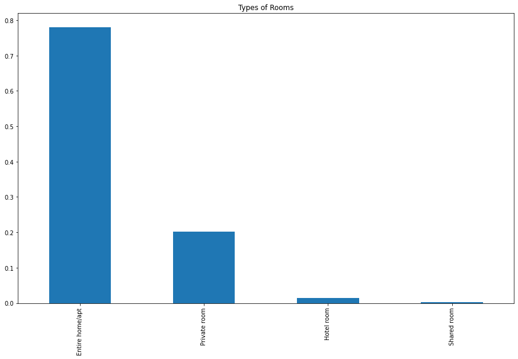

```python
# Checking room types
plt.figure(figsize = (15, 9))
room_types = listings_df.room_type.value_counts()

(room_types / listings_df.shape[0]).plot(kind = "bar");
plt.title("Types of Rooms");
```

```python
# Types of rooms
room_types.reset_index()
```

|  | index | room_type |
| --- | --- | --- |
| 0 | Entire home/apt | 15107 |
| 1 | Private room | 3918 |
| 2 | Hotel room | 267 |
| 3 | Shared room | 60 |

#### Distribution of Neighbourhood

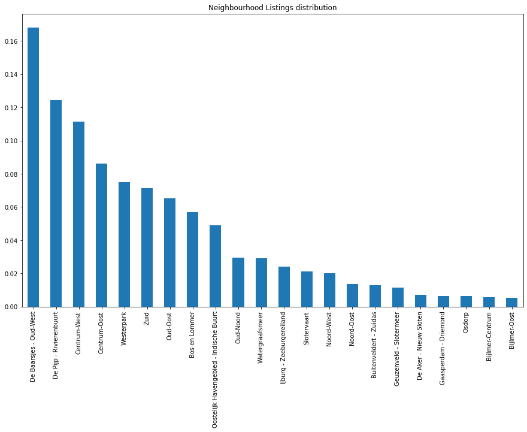

```python
# Distribution of Neighbourhood
plt.figure(figsize = (15, 9))
neighbourhood = listings_df.neighbourhood.value_counts()

(neighbourhood / listings_df.shape[0]).plot(kind = "bar");
plt.title("Neighbourhood Listings distribution");
```

```python
# Tabular view of neighbourhoods
neighbourhood.reset_index()
```

|  | index | neighbourhood |
| --- | --- | --- |
| 0 | De Baarsjes - Oud-West | 3252 |
| 1 | De Pijp - Rivierenbuurt | 2404 |
| 2 | Centrum-West | 2152 |
| 3 | Centrum-Oost | 1668 |
| 4 | Westerpark | 1448 |
| 5 | Zuid | 1382 |
| 6 | Oud-Oost | 1264 |
| 7 | Bos en Lommer | 1102 |
| 8 | Oostelijk Havengebied - Indische Buurt | 949 |
| 9 | Oud-Noord | 574 |
| 10 | Watergraafsmeer | 561 |
| 11 | IJburg - Zeeburgereiland | 465 |
| 12 | Slotervaart | 411 |
| 13 | Noord-West | 387 |
| 14 | Noord-Oost | 266 |
| 15 | Buitenveldert - Zuidas | 247 |
| 16 | Geuzenveld - Slotermeer | 220 |
| 17 | De Aker - Nieuw Sloten | 138 |
| 18 | Gaasperdam - Driemond | 125 |
| 19 | Osdorp | 123 |
| 20 | Bijlmer-Centrum | 113 |
| 21 | Bijlmer-Oost | 101 |

#### Number of Reviews

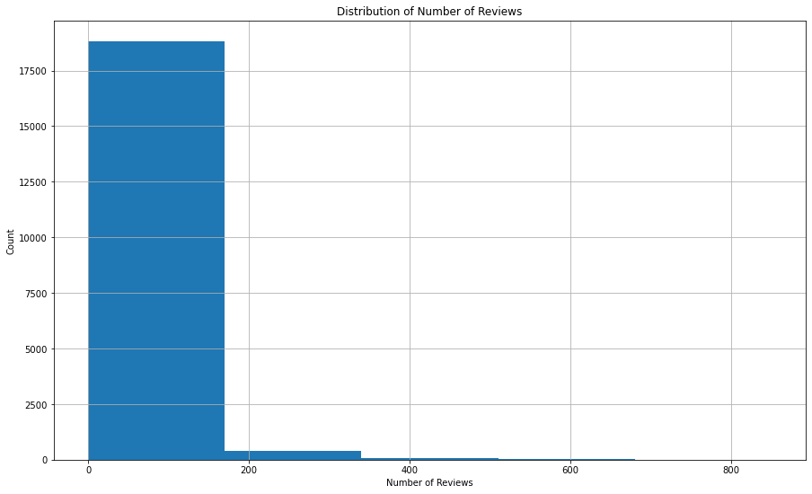

```python
# Number of reviews
plt.figure(figsize = (15, 9))

(listings_df.number_of_reviews).hist(bins = 5);
plt.title('Distribution of Number of Reviews');
plt.xlabel('Number of Reviews');
plt.ylabel('Count');
```

#### Price Distribution

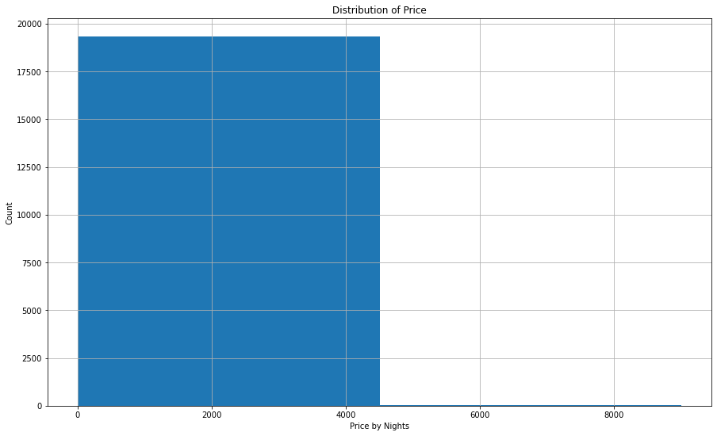

```python
# Distribution of Price
plt.figure(figsize = (15, 9))

listings_df.price.hist(bins = 2);
plt.title('Distribution of Price');
plt.xlabel('Price by Nights');
plt.ylabel('Count');
```

```python
# Summary or stats of the data
listings_df[['reviews_per_month','number_of_reviews','calculated_host_listings_count','price','minimum_nights','availability_365']].describe()
```

|  | reviews_per_month | number_of_reviews | calculated_host_listings_count | price | minimum_nights | availability_365 |
| --- | --- | --- | --- | --- | --- | --- |
| count | 16960.000000 | 19352.000000 | 19352.000000 | 19352.000000 | 19352.000000 | 19352.000000 |
| mean | 0.744867 | 24.924607 | 2.173729 | 165.933340 | 3.509663 | 61.542115 |
| std | 1.216225 | 53.892550 | 6.147742 | 236.859423 | 13.551495 | 108.154091 |
| min | 0.010000 | 0.000000 | 1.000000 | 5.000000 | 1.000000 | 0.000000 |
| 25% | 0.170000 | 2.000000 | 1.000000 | 99.000000 | 2.000000 | 0.000000 |
| 50% | 0.380000 | 9.000000 | 1.000000 | 130.000000 | 2.000000 | 0.000000 |
| 75% | 0.770000 | 23.000000 | 1.000000 | 188.000000 | 3.000000 | 87.000000 |
| max | 50.000000 | 850.000000 | 78.000000 | 9000.000000 | 1001.000000 | 365.000000 |

*The summarized listing csv contains 19352 rows and 16 columns that cover the listing details such as id, name, location(longitude, latitude),room type and price and host related information though it is limited to host name and id.*

**Consider in the wrangling phase:**

- Neighbourhood_group is null for all the values so this column will be dropped
- Last_review is a string instead of a date

#### Importing Calendar Data

```python
# Importing Calendar data
calender_df = pd.read_csv("calendar.csv")
calender_df.head()
```

|  | listing_id | date | available | price | adjusted_price | minimum_nights | maximum_nights |
| --- | --- | --- | --- | --- | --- | --- | --- |
| 0 | 200461 | 2020-06-10 | f | $71.00 | $71.00 | 5.0 | 30.0 |
| 1 | 200461 | 2020-06-11 | f | $71.00 | $71.00 | 5.0 | 30.0 |
| 2 | 200461 | 2020-06-12 | f | $71.00 | $71.00 | 5.0 | 30.0 |
| 3 | 200461 | 2020-06-13 | f | $71.00 | $71.00 | 5.0 | 30.0 |
| 4 | 200461 | 2020-06-14 | f | $71.00 | $71.00 | 5.0 | 30.0 |

```python
# Data info
calender_df.info(null_counts = True)
```

```
<class 'pandas.core.frame.DataFrame'>
RangeIndex: 7063480 entries, 0 to 7063479
Data columns (total 7 columns):
 #   Column          Non-Null Count    Dtype
---  ------          --------------    -----
 0   listing_id      7063480 non-null  int64
 1   date            7063480 non-null  object
 2   available       7063480 non-null  object
 3   price           7063289 non-null  object
 4   adjusted_price  7063289 non-null  object
 5   minimum_nights  7063479 non-null  float64
 6   maximum_nights  7063479 non-null  float64
dtypes: float64(2), int64(1), object(4)
memory usage: 377.2+ MB
```

```python
# Checking columns with no missing values
set(calender_df.columns[calender_df.isnull().mean() == 0])
```

```
{'available', 'date', 'listing_id'}
```

```python
# Checking columns with more than 75% missing values
set(calender_df.columns[calender_df.isnull().mean()>= 0.75])
```

```
set()
```

```python
# Summary or stats of the calender dataframe
calender_df.describe()
```

|  | listing_id | minimum_nights | maximum_nights |
| --- | --- | --- | --- |
| count | 7.063480e+06 | 7.063479e+06 | 7.063479e+06 |
| mean | 1.980185e+07 | 3.607395e+00 | 2.226270e+05 |
| std | 1.215331e+07 | 1.358404e+01 | 2.183029e+07 |
| min | 2.818000e+03 | 1.000000e+00 | 1.000000e+00 |
| 25% | 9.800166e+06 | 2.000000e+00 | 2.500000e+01 |
| 50% | 1.871935e+07 | 2.000000e+00 | 1.125000e+03 |
| 75% | 2.917511e+07 | 3.000000e+00 | 1.125000e+03 |
| max | 4.370908e+07 | 1.001000e+03 | 2.147484e+09 |

*This detailed calendar csv contains 7 columns that has a listing and availability for a certain date.*

**Consider in the Wrangling Phase:**

- Date is a string and needs to be changed into date format
- Price is set to a string
- The max value for a minimum night for a listing is 1000
- We have some missing price items in the calander data
- Drop the adjusted price and the missing values for price

#### Detailed Listing Dataset

```python
# Detailed_listing Dataset
detailed_listings_df = pd.read_csv('detailed_listings.csv')
detailed_listings_df.head()
```

|  | id | listing_url | scrape_id | last_scraped | name | summary | space | description | experiences_offered | neighborhood_overview | ... | instant_bookable | is_business_travel_ready | cancellation_policy | require_guest_profile_picture | require_guest_phone_verification | calculated_host_listings_count | calculated_host_listings_count_entire_homes | calculated_host_listings_count_private_rooms | calculated_host_listings_count_shared_rooms | reviews_per_month |
| --- | --- | --- | --- | --- | --- | --- | --- | --- | --- | --- | --- | --- | --- | --- | --- | --- | --- | --- | --- | --- | --- |
| 0 | 2818 | https://www.airbnb.com/rooms/2818 | 20200608201310 | 2020-06-10 | Quiet Garden View Room & Super Fast WiFi | Quiet Garden View Room & Super Fast WiFi | I'm renting a bedroom (room overlooking the ga... | Quiet Garden View Room & Super Fast WiFi I'm r... | none | Indische Buurt ("Indies Neighborhood") is a ne... | ... | t | f | strict_14_with_grace_period | f | f | 1 | 0 | 1 | 0 | 2.04 |
| 1 | 9693 | https://www.airbnb.com/rooms/9693 | 20200608201310 | 2020-06-10 | Top Location on Canal (Center Flat) | You will love your stay here. It is a beautifu... | This beautiful apartment in the heart of 17th ... | You will love your stay here. It is a beautifu... | none | You will be on a beautiful quite canal and wil... | ... | t | f | moderate | f | f | 1 | 1 | 0 | 0 | 0.44 |
| 2 | 20168 | https://www.airbnb.com/rooms/20168 | 20200608201310 | 2020-06-10 | Studio with private bathroom in the centre 1 | 17th century Dutch townhouse in the heart of t... | For those who like all facets of city life. In... | 17th century Dutch townhouse in the heart of t... | none | Located just in between famous central canals.... | ... | t | f | strict_14_with_grace_period | f | f | 2 | 0 | 2 | 0 | 2.72 |
| 3 | 25428 | https://www.airbnb.com/rooms/25428 | 20200608201310 | 2020-06-10 | Lovely apt in City Centre (w.lift) near Jordaan | Lovely apt in Centre ( lift & fireplace) near ... | This nicely furnished, newly renovated apt is... | Lovely apt in Centre ( lift & fireplace) near ... | none | NaN | ... | f | f | strict_14_with_grace_period | f | f | 1 | 1 | 0 | 0 | 0.17 |
| 4 | 27886 | https://www.airbnb.com/rooms/27886 | 20200608201310 | 2020-06-10 | Romantic, stylish B&B houseboat in canal district | Stylish and romantic houseboat on fantastic hi... | For a romantic couple: A beautifully restored ... | Stylish and romantic houseboat on fantastic hi... | none | Central, quiet, safe, clean and beautiful. | ... | t | f | strict_14_with_grace_period | f | f | 1 | 0 | 1 | 0 | 2.12 |

5 rows × 106 columns

```python
# Dataset info
detailed_listings_df.info()
```

```
<class 'pandas.core.frame.DataFrame'>
RangeIndex: 19352 entries, 0 to 19351
Columns: 106 entries, id to reviews_per_month
dtypes: float64(22), int64(21), object(63)
memory usage: 15.7+ MB
```

```python
# Checking Columns with no missing values
set(detailed_listings_df.columns[detailed_listings_df.isnull().mean() == 0])
```

```
{'accommodates',
 'amenities',
 'availability_30',
 'availability_365',
 'availability_60',
 'availability_90',
 'bed_type',
 'calculated_host_listings_count',
 'calculated_host_listings_count_entire_homes',
 'calculated_host_listings_count_private_rooms',
 'calculated_host_listings_count_shared_rooms',
 'calendar_last_scraped',
 'calendar_updated',
 'cancellation_policy',
 'country',
 'country_code',
 'experiences_offered',
 'extra_people',
 'guests_included',
 'has_availability',
 'host_id',
 'host_url',
 'host_verifications',
 'id',
 'instant_bookable',
 'is_business_travel_ready',
 'is_location_exact',
 'last_scraped',
 'latitude',
 'listing_url',
 'longitude',
 'maximum_maximum_nights',
 'maximum_minimum_nights',
 'maximum_nights',
 'maximum_nights_avg_ntm',
 'minimum_maximum_nights',
 'minimum_minimum_nights',
 'minimum_nights',
 'minimum_nights_avg_ntm',
 'neighbourhood_cleansed',
 'number_of_reviews',
 'number_of_reviews_ltm',
 'picture_url',
 'price',
 'property_type',
 'require_guest_phone_verification',
 'require_guest_profile_picture',
 'requires_license',
 'room_type',
 'scrape_id',
 'smart_location',
 'street'}
```

```python
# Checking columns with more than 75 percent missing values
set(detailed_listings_df.columns[detailed_listings_df.isnull().mean()>= 0.75])
```

```
{'host_response_rate',
 'host_response_time',
 'license',
 'medium_url',
 'monthly_price',
 'neighbourhood_group_cleansed',
 'square_feet',
 'thumbnail_url',
 'weekly_price',
 'xl_picture_url'}
```

```python
# Checking Columns with more than 100% missing values
set(detailed_listings_df.columns[detailed_listings_df.isnull().mean()>= 1])
```

```
{'medium_url',
 'neighbourhood_group_cleansed',
 'thumbnail_url',
 'xl_picture_url'}
```

```python
# Checking Columns in this data set
detailed_listings_df.columns.tolist()
```

```
['id',
 'listing_url',
 'scrape_id',
 'last_scraped',
 'name',
 'summary',
 'space',
 'description',
 'experiences_offered',
 'neighborhood_overview',
 'notes',
 'transit',
 'access',
 'interaction',
 'house_rules',
 'thumbnail_url',
 'medium_url',
 'picture_url',
 'xl_picture_url',
 'host_id',
 'host_url',
 'host_name',
 'host_since',
 'host_location',
 'host_about',
 'host_response_time',
 'host_response_rate',
 'host_acceptance_rate',
 'host_is_superhost',
 'host_thumbnail_url',
 'host_picture_url',
 'host_neighbourhood',
 'host_listings_count',
 'host_total_listings_count',
 'host_verifications',
 'host_has_profile_pic',
 'host_identity_verified',
 'street',
 'neighbourhood',
 'neighbourhood_cleansed',
```

[output cut: 51 more lines]

```
 'review_scores_location',
 'review_scores_value',
 'requires_license',
 'license',
 'jurisdiction_names',
 'instant_bookable',
 'is_business_travel_ready',
 'cancellation_policy',
 'require_guest_profile_picture',
 'require_guest_phone_verification',
 'calculated_host_listings_count',
 'calculated_host_listings_count_entire_homes',
 'calculated_host_listings_count_private_rooms',
 'calculated_host_listings_count_shared_rooms',
 'reviews_per_month']
```

**Consider in the wrangling phase:**

- Decide on columns of interest
- Remove columns with more than 75% missing columns
- Observe the issues from listings dataset

## Data Wrangling

### Calendar dataset

- Change the date column from string to datetime format
- Price is set to a string and is need to fixing the format

```python
# Change the date column to a datetime
calender_df.date = pd.to_datetime(calender_df.date)
calender_df.info(verbose = True, null_counts = True)
```

```
<class 'pandas.core.frame.DataFrame'>
RangeIndex: 7063480 entries, 0 to 7063479
Data columns (total 7 columns):
 #   Column          Non-Null Count    Dtype
---  ------          --------------    -----
 0   listing_id      7063480 non-null  int64
 1   date            7063480 non-null  datetime64[ns]
 2   available       7063480 non-null  object
 3   price           7063289 non-null  object
 4   adjusted_price  7063289 non-null  object
 5   minimum_nights  7063479 non-null  float64
 6   maximum_nights  7063479 non-null  float64
dtypes: datetime64[ns](1), float64(2), int64(1), object(3)
memory usage: 377.2+ MB
```

```python
# dropping the missing values in price
calender_df = calender_df.dropna(subset = ['price'], axis = 0)
calender_df.info(verbose = True, null_counts = True)
```

```
<class 'pandas.core.frame.DataFrame'>
Int64Index: 7063289 entries, 0 to 7063479
Data columns (total 7 columns):
 #   Column          Non-Null Count    Dtype
---  ------          --------------    -----
 0   listing_id      7063289 non-null  int64
 1   date            7063289 non-null  datetime64[ns]
 2   available       7063289 non-null  object
 3   price           7063289 non-null  object
 4   adjusted_price  7063289 non-null  object
 5   minimum_nights  7063288 non-null  float64
 6   maximum_nights  7063288 non-null  float64
dtypes: datetime64[ns](1), float64(2), int64(1), object(3)
memory usage: 431.1+ MB
```

```python
def clean_price(x):
    """
    clean the price column by eliminate the $ and ,
    from the string and return a float to be stored in the column
    """
    try:
        if ',' in x:
            x = x.replace(',','')
        x = x[1:]
        return float(str(x))
    except:
        return x
```

```python
# to clean the price and convert it into a float
calender_df.price = calender_df.price.apply(lambda x: clean_price(x))
calender_df.info(verbose = True, null_counts = True)
```

```
<class 'pandas.core.frame.DataFrame'>
Int64Index: 7063289 entries, 0 to 7063479
Data columns (total 7 columns):
 #   Column          Non-Null Count    Dtype
---  ------          --------------    -----
 0   listing_id      7063289 non-null  int64
 1   date            7063289 non-null  datetime64[ns]
 2   available       7063289 non-null  object
 3   price           7063289 non-null  float64
 4   adjusted_price  7063289 non-null  object
 5   minimum_nights  7063288 non-null  float64
 6   maximum_nights  7063288 non-null  float64
dtypes: datetime64[ns](1), float64(3), int64(1), object(2)
memory usage: 431.1+ MB
```

```python
# dropping the adjusted price column
calender_df.drop('adjusted_price', axis = 1, inplace = True)
calender_df.info(verbose = True, null_counts = True)
```

```
<class 'pandas.core.frame.DataFrame'>
Int64Index: 7063289 entries, 0 to 7063479
Data columns (total 6 columns):
 #   Column          Non-Null Count    Dtype
---  ------          --------------    -----
 0   listing_id      7063289 non-null  int64
 1   date            7063289 non-null  datetime64[ns]
 2   available       7063289 non-null  object
 3   price           7063289 non-null  float64
 4   minimum_nights  7063288 non-null  float64
 5   maximum_nights  7063288 non-null  float64
dtypes: datetime64[ns](1), float64(3), int64(1), object(1)
memory usage: 377.2+ MB
```

```python
# Summary of the data
calender_df.describe()
```

|  | listing_id | price | minimum_nights | maximum_nights |
| --- | --- | --- | --- | --- |
| count | 7.063289e+06 | 7.063289e+06 | 7.063288e+06 | 7.063288e+06 |
| mean | 1.980160e+07 | 1.660279e+02 | 3.607435e+00 | 2.226330e+05 |
| std | 1.215338e+07 | 1.508649e+02 | 1.358422e+01 | 2.183058e+07 |
| min | 2.818000e+03 | 6.000000e+00 | 1.000000e+00 | 1.000000e+00 |
| 25% | 9.799875e+06 | 1.000000e+02 | 2.000000e+00 | 2.500000e+01 |
| 50% | 1.871859e+07 | 1.390000e+02 | 2.000000e+00 | 1.125000e+03 |
| 75% | 2.917543e+07 | 1.990000e+02 | 3.000000e+00 | 1.125000e+03 |
| max | 4.370908e+07 | 1.086200e+04 | 1.001000e+03 | 2.147484e+09 |

```python
# adding month and year column to the calender dataset
calender_df['month'], calender_df['year'] = calender_df.date.dt.month, calender_df.date.dt.year
calender_df.info(verbose = True, null_counts = True)
```

```
<class 'pandas.core.frame.DataFrame'>
Int64Index: 7063289 entries, 0 to 7063479
Data columns (total 8 columns):
 #   Column          Non-Null Count    Dtype
---  ------          --------------    -----
 0   listing_id      7063289 non-null  int64
 1   date            7063289 non-null  datetime64[ns]
 2   available       7063289 non-null  object
 3   price           7063289 non-null  float64
 4   minimum_nights  7063288 non-null  float64
 5   maximum_nights  7063288 non-null  float64
 6   month           7063289 non-null  int64
 7   year            7063289 non-null  int64
dtypes: datetime64[ns](1), float64(3), int64(3), object(1)
memory usage: 485.0+ MB
```

```python
# Summary or stats of data
calender_df.describe()
```

|  | listing_id | price | minimum_nights | maximum_nights | month | year |
| --- | --- | --- | --- | --- | --- | --- |
| count | 7.063289e+06 | 7.063289e+06 | 7.063288e+06 | 7.063288e+06 | 7.063289e+06 | 7.063289e+06 |
| mean | 1.980160e+07 | 1.660279e+02 | 3.607435e+00 | 2.226330e+05 | 6.525963e+00 | 2.020437e+03 |
| std | 1.215338e+07 | 1.508649e+02 | 1.358422e+01 | 2.183058e+07 | 3.447863e+00 | 4.959653e-01 |
| min | 2.818000e+03 | 6.000000e+00 | 1.000000e+00 | 1.000000e+00 | 1.000000e+00 | 2.020000e+03 |
| 25% | 9.799875e+06 | 1.000000e+02 | 2.000000e+00 | 2.500000e+01 | 4.000000e+00 | 2.020000e+03 |
| 50% | 1.871859e+07 | 1.390000e+02 | 2.000000e+00 | 1.125000e+03 | 7.000000e+00 | 2.020000e+03 |
| 75% | 2.917543e+07 | 1.990000e+02 | 3.000000e+00 | 1.125000e+03 | 1.000000e+01 | 2.021000e+03 |
| max | 4.370908e+07 | 1.086200e+04 | 1.001000e+03 | 2.147484e+09 | 1.200000e+01 | 2.021000e+03 |

### Price by Months checking which months or season might be expensive

*Comparing the availabilty of the listing to the price by checking the availability in each month*

```python
# Checking availability counts
calender_df.available.value_counts()
```

```
f    5865655
t    1197634
Name: available, dtype: int64
```

```python
not_available = calender_df.available == 'f'
available = calender_df.available == 't'
```

```python
calender_df.groupby(['month','available']).mean()['price'].unstack()
```

| available month | f | t |
| --- | --- | --- |
| 1 | 158.542127 | 211.573684 |
| 2 | 158.147652 | 211.990153 |
| 3 | 159.365249 | 210.658087 |
| 4 | 161.150198 | 218.329888 |
| 5 | 161.016061 | 219.022037 |
| 6 | 156.360017 | 197.117058 |
| 7 | 151.849828 | 197.720795 |
| 8 | 152.828458 | 200.460500 |
| 9 | 154.658497 | 209.031751 |
| 10 | 156.077045 | 216.489093 |
| 11 | 156.701738 | 207.648223 |
| 12 | 159.379572 | 219.686310 |

```python
# Number of Available Homes
available_home_count = calender_df.groupby('date').count()[['price']]
available_home_count = available_home_count.rename({'price' : "total_available_houses"}, axis = 1)
```

```python
available_home_count.total_available_houses.value_counts()
```

```
19351    189
19352    173
17909      1
2541       1
16811      1
1442       1
8024       1
11327      1
Name: total_available_houses, dtype: int64
```

### Comparing the availabilty to the Price

```python
available_count_daily = calender_df[available].groupby('date').count()[['price']]
available_count_daily = available_count_daily.rename({"price":"total_available_houses"}, axis = 1)
```

```python
average_price_daily = calender_df[available].groupby('date').mean()[['price']]
# change column name
average_price_daily = average_price_daily.rename({"price":"average_prices"}, axis = 1)
```

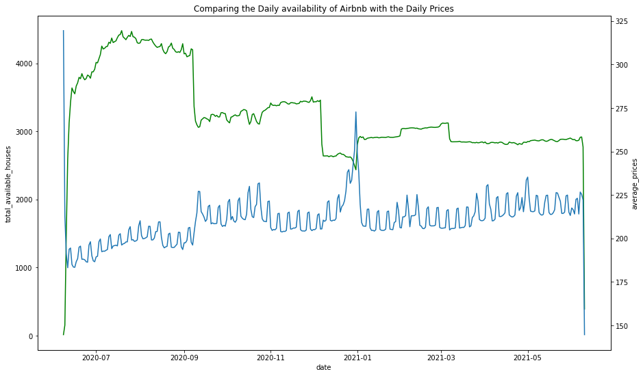

```python
# plotting total available houses and average prices
f, ax = plt.subplots(figsize = (15, 9))

plt1 = sns.lineplot(x = available_count_daily.index, y = 'total_available_houses',
                  data = available_count_daily, color = "green")

ax2 = ax.twinx()

plt2 = sns.lineplot(x = average_price_daily.index, y = 'average_prices',
             data = average_price_daily, ax = ax2, linestyle = ':')

ax.set_title('Comparing the Daily availability of Airbnb with the Daily Prices');
```

### Expensive Months to visit Amsterdam

*Comparing the monthly availability and average monthly prices.*

```python
average_price_monthly = calender_df[available].groupby('month').mean()[['price']]
average_price_monthly = average_price_monthly.rename({"price":"monthly_average_prices"}, axis = 1)
```

```python
available_count_monthly = calender_df[available].groupby('month').count()[['price']]
available_count_monthly = available_count_monthly.rename({"price":"total_available_houses_monthly"}, axis = 1)
```

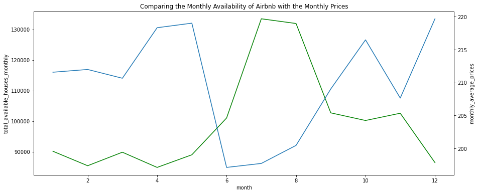

```python
# plotting total available houses and average monthly prices

f, ax = plt.subplots(figsize=(15, 6))

plt1 = sns.lineplot(x = available_count_monthly.index, y = 'total_available_houses_monthly',
                  data = available_count_monthly, color = "green")
ax.set_xticks

ax2 = ax.twinx()

plt2 = sns.lineplot(x = average_price_monthly.index, y = 'monthly_average_prices',
             data = average_price_monthly, ax = ax2, linestyle = ':')

ax.set_title('Comparing the Monthly Availability of Airbnb with the Monthly Prices');
```

### Listings Dataset

Cleaning and Handling Categorical Variables:

- neighbourhood_group is null for all the values so this column will be dropped.
- last_review, first_review, host_since is a string instead of a date

### Most expensive and least expensive Neighbourhoods in Amsterdam

```python
# group the listings by neighbourood and get the average price
listings_df.groupby('neighbourhood')['price'].mean().sort_values(ascending = False)
```

```
neighbourhood
Centrum-West                              227.883364
Centrum-Oost                              222.962830
Zuid                                      181.554993
IJburg - Zeeburgereiland                  169.944086
Oud-Noord                                 168.797909
De Pijp - Rivierenbuurt                   168.406406
Buitenveldert - Zuidas                    152.757085
Westerpark                                152.751381
Oud-Oost                                  151.174051
De Baarsjes - Oud-West                    151.167897
Watergraafsmeer                           144.192513
Oostelijk Havengebied - Indische Buurt    138.207587
De Aker - Nieuw Sloten                    136.623188
Noord-Oost                                129.718045
Noord-West                                128.333333
Geuzenveld - Slotermeer                   127.354545
Slotervaart                               125.019465
Bos en Lommer                             123.893829
Osdorp                                    109.796748
Gaasperdam - Driemond                      94.368000
Bijlmer-Oost                               91.950495
Bijlmer-Centrum                            88.238938
Name: price, dtype: float64
```

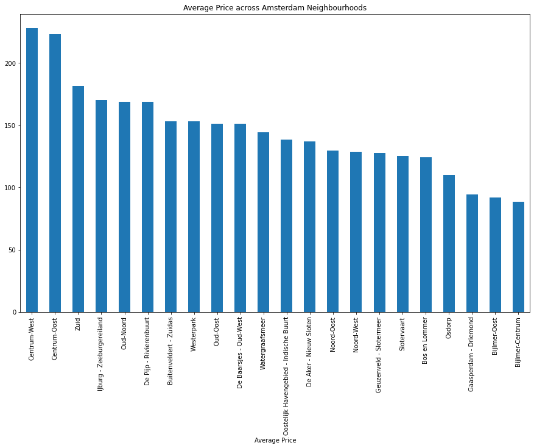

```python
# grouped by neighbourhoods

(listings_df.groupby('neighbourhood')['price'].mean().sort_values(ascending = False)).plot(kind = "bar", figsize = (15, 9));

plt.title("Average Price across Amsterdam Neighbourhoods");
plt.xlabel('Neighbourhoods');
plt.xlabel('Average Price');
```

**Insights:**

- The Most Expensive neighbourhood is Centrum-West followed by Centrum-Oost while the cheapest listings are in Bijlmer-Centrum and Bijlmer-Oost which is part of Amsterdam-Southeast.
- The prices in the central towns is about double the prices in the southeast and westernmost neighbourhoods of Amsterdam.

### Data Wrangling

- Drop redundant columns: some of the columns are present twice such as neighbourhood and neighbourhood_cleansed
- Handle the missing values by removing columns containing more than 75% missing values.
- Handle Categorical variables by enconding them so that they are useful for the training.

#### Detailed Listings Data Wrangling

#### Remove Redundent Columns

```python
# Info of the data
detailed_listings_df.info()
```

```
<class 'pandas.core.frame.DataFrame'>
RangeIndex: 19352 entries, 0 to 19351
Columns: 106 entries, id to reviews_per_month
dtypes: float64(22), int64(21), object(63)
memory usage: 15.7+ MB
```

```python
# dropping unneccessary columns
detailed_listings_df.drop(columns = 'neighbourhood' , inplace = True, axis = 1)
detailed_listings_df.info()
```

```
<class 'pandas.core.frame.DataFrame'>
RangeIndex: 19352 entries, 0 to 19351
Columns: 105 entries, id to reviews_per_month
dtypes: float64(22), int64(21), object(62)
memory usage: 15.5+ MB
```

#### Handling missing values

```python
# columns with more than 75% missing values
cols_with_missing_val = list(set(detailed_listings_df.columns[detailed_listings_df.isnull().mean()>0.750]))
cols_with_missing_val
```

```
['neighbourhood_group_cleansed',
 'weekly_price',
 'host_response_rate',
 'square_feet',
 'monthly_price',
 'thumbnail_url',
 'host_response_time',
 'license',
 'medium_url',
 'xl_picture_url']
```

```python
# drop columns with more than 75% null values
detailed_listings_df.drop(columns = cols_with_missing_val , inplace = True, axis = 1)
```

```python
detailed_listings_df.describe()
```

|  | id | scrape_id | host_id | host_listings_count | host_total_listings_count | latitude | longitude | accommodates | bathrooms | bedrooms | ... | review_scores_cleanliness | review_scores_checkin | review_scores_communication | review_scores_location | review_scores_value | calculated_host_listings_count | calculated_host_listings_count_entire_homes | calculated_host_listings_count_private_rooms | calculated_host_listings_count_shared_rooms | reviews_per_month |
| --- | --- | --- | --- | --- | --- | --- | --- | --- | --- | --- | --- | --- | --- | --- | --- | --- | --- | --- | --- | --- | --- |
| count | 1.935200e+04 | 1.935200e+04 | 1.935200e+04 | 19341.000000 | 19341.000000 | 19352.000000 | 19352.000000 | 19352.000000 | 19346.000000 | 19334.000000 | ... | 16728.000000 | 16719.000000 | 16727.000000 | 16721.000000 | 16721.000000 | 19352.000000 | 19352.000000 | 19352.000000 | 19352.000000 | 16960.000000 |
| mean | 1.980185e+07 | 2.020061e+13 | 6.324503e+07 | 3.476397 | 3.476397 | 52.365346 | 4.889703 | 2.859291 | 1.191926 | 1.453605 | ... | 9.475849 | 9.762306 | 9.805584 | 9.513546 | 9.201244 | 2.173729 | 1.656160 | 0.423936 | 0.011213 | 0.744867 |
| std | 1.215362e+07 | 6.500168e+00 | 7.990810e+07 | 21.308929 | 21.308929 | 0.016475 | 0.035910 | 1.294356 | 0.391324 | 0.894123 | ... | 0.878057 | 0.629146 | 0.604388 | 0.695989 | 0.809476 | 6.147742 | 5.875326 | 1.332524 | 0.214527 | 1.216225 |
| min | 2.818000e+03 | 2.020061e+13 | 3.159000e+03 | 0.000000 | 0.000000 | 52.289270 | 4.755720 | 1.000000 | 0.000000 | 0.000000 | ... | 2.000000 | 2.000000 | 2.000000 | 2.000000 | 2.000000 | 1.000000 | 0.000000 | 0.000000 | 0.000000 | 0.010000 |
| 25% | 9.800166e+06 | 2.020061e+13 | 9.012687e+06 | 1.000000 | 1.000000 | 52.355090 | 4.863935 | 2.000000 | 1.000000 | 1.000000 | ... | 9.000000 | 10.000000 | 10.000000 | 9.000000 | 9.000000 | 1.000000 | 1.000000 | 0.000000 | 0.000000 | 0.170000 |
| 50% | 1.871935e+07 | 2.020061e+13 | 2.700337e+07 | 1.000000 | 1.000000 | 52.364690 | 4.887185 | 2.000000 | 1.000000 | 1.000000 | ... | 10.000000 | 10.000000 | 10.000000 | 10.000000 | 9.000000 | 1.000000 | 1.000000 | 0.000000 | 0.000000 | 0.380000 |
| 75% | 2.917511e+07 | 2.020061e+13 | 8.357914e+07 | 1.000000 | 1.000000 | 52.375270 | 4.909343 | 4.000000 | 1.500000 | 2.000000 | ... | 10.000000 | 10.000000 | 10.000000 | 10.000000 | 10.000000 | 1.000000 | 1.000000 | 0.000000 | 0.000000 | 0.770000 |
| max | 4.370908e+07 | 2.020061e+13 | 3.491220e+08 | 673.000000 | 673.000000 | 52.425120 | 5.027690 | 17.000000 | 8.000000 | 12.000000 | ... | 10.000000 | 10.000000 | 10.000000 | 10.000000 | 10.000000 | 78.000000 | 76.000000 | 19.000000 | 8.000000 | 50.000000 |

8 rows × 38 columns

#### Handling Text Fields

- Adding binary columns to signify the existance of a value in the following columns: (transit, space, summary, description, neighborhood_overview, host_about) with a 1 if it contains a value and 0 otherwise.
- Fix columns with t and f to binary: instant bookable and require_guest_phone_verification

```python
# Creating New Columns

detailed_listings_df['has_transit_info'] = detailed_listings_df.transit.apply(lambda x: 0 if pd.isnull(x) else 1)
detailed_listings_df['has_description_info'] = detailed_listings_df.description.apply(lambda x: 0 if pd.isnull(x) else 1)
detailed_listings_df['has_summary_info'] = detailed_listings_df.summary.apply(lambda x: 0 if pd.isnull(x) else 1)
detailed_listings_df['has_neighborhood_info'] = detailed_listings_df.neighborhood_overview.apply(lambda x: 0 if pd.isnull(x) else 1)
detailed_listings_df['has_host_info'] = detailed_listings_df.host_about.apply(lambda x: 0 if pd.isnull(x) else 1)
detailed_listings_df.host_is_superhost = detailed_listings_df.host_is_superhost.apply(lambda x: 0 if pd.isnull(x) else 1)

# fixing t and f columns
detailed_listings_df['instant_bookable'] =  detailed_listings_df['instant_bookable'].apply(lambda x: 1 if x=='t' else 0)
detailed_listings_df['require_guest_phone_verification'] =  detailed_listings_df['require_guest_phone_verification'].apply(lambda x: 1 if x=='t' else 0)
detailed_listings_df['require_guest_profile_picture'] =  detailed_listings_df['require_guest_profile_picture'].apply(lambda x: 1 if x=='t' else 0)
detailed_listings_df['host_identity_verified'] =  detailed_listings_df['host_identity_verified'].apply(lambda x: 1 if x=='t' else 0)
detailed_listings_df.host_has_profile_pic = detailed_listings_df.host_has_profile_pic.apply(lambda x: 1 if x=='t' else 0)
```

```python
# Info of the current data
detailed_listings_df.info()
```

```
<class 'pandas.core.frame.DataFrame'>
RangeIndex: 19352 entries, 0 to 19351
Data columns (total 100 columns):
 #   Column                                        Non-Null Count  Dtype
---  ------                                        --------------  -----
 0   id                                            19352 non-null  int64
 1   listing_url                                   19352 non-null  object
 2   scrape_id                                     19352 non-null  int64
 3   last_scraped                                  19352 non-null  object
 4   name                                          19319 non-null  object
 5   summary                                       18736 non-null  object
 6   space                                         14294 non-null  object
 7   description                                   19115 non-null  object
 8   experiences_offered                           19352 non-null  object
 9   neighborhood_overview                         13420 non-null  object
```

[output cut: 92 more lines]

#### Drop Irrelevant Columns:

```python
detailed_listings_df.select_dtypes(include = ['object']).columns
```

```
Index(['listing_url', 'last_scraped', 'name', 'summary', 'space',
       'description', 'experiences_offered', 'neighborhood_overview', 'notes',
       'transit', 'access', 'interaction', 'house_rules', 'picture_url',
       'host_url', 'host_name', 'host_since', 'host_location', 'host_about',
       'host_acceptance_rate', 'host_thumbnail_url', 'host_picture_url',
       'host_neighbourhood', 'host_verifications', 'street',
       'neighbourhood_cleansed', 'city', 'state', 'zipcode', 'market',
       'smart_location', 'country_code', 'country', 'is_location_exact',
       'property_type', 'room_type', 'bed_type', 'amenities', 'price',
       'security_deposit', 'cleaning_fee', 'extra_people', 'calendar_updated',
       'has_availability', 'calendar_last_scraped', 'first_review',
       'last_review', 'requires_license', 'jurisdiction_names',
       'is_business_travel_ready', 'cancellation_policy'],
      dtype='object')
```

```python
# Dropping columns
columns_to_drop = ['listing_url', 'scrape_id', 'last_scraped', 'country_code', 'country', 'picture_url', 'host_url', 'host_thumbnail_url','notes',
'host_picture_url','transit', 'space', 'description', 'summary', 'neighborhood_overview', 'name', 'latitude', 'longitude'
, 'is_location_exact', 'host_about','is_business_travel_ready','jurisdiction_names','experiences_offered','access', 'interaction',
'house_rules', 'amenities','calendar_last_scraped','requires_license', 'smart_location', 'host_verifications', 'street',
'host_verifications', 'calendar_updated','has_availability', 'city', 'state','host_id','zipcode','market','host_location','host_name','host_neighbourhood']

detailed_listings_df.drop(columns = columns_to_drop, inplace = True)
detailed_listings_df.info()
```

```
<class 'pandas.core.frame.DataFrame'>
RangeIndex: 19352 entries, 0 to 19351
Data columns (total 58 columns):
 #   Column                                        Non-Null Count  Dtype
---  ------                                        --------------  -----
 0   id                                            19352 non-null  int64
 1   host_since                                    19341 non-null  object
 2   host_acceptance_rate                          12570 non-null  object
 3   host_is_superhost                             19352 non-null  int64
 4   host_listings_count                           19341 non-null  float64
 5   host_total_listings_count                     19341 non-null  float64
 6   host_has_profile_pic                          19352 non-null  int64
 7   host_identity_verified                        19352 non-null  int64
 8   neighbourhood_cleansed                        19352 non-null  object
 9   property_type                                 19352 non-null  object
```

[output cut: 50 more lines]

```python
# Columns with string data type
detailed_listings_df.select_dtypes(include = ['object']).columns
```

```
Index(['host_since', 'host_acceptance_rate', 'neighbourhood_cleansed',
       'property_type', 'room_type', 'bed_type', 'price', 'security_deposit',
       'cleaning_fee', 'extra_people', 'first_review', 'last_review',
       'cancellation_policy'],
      dtype='object')
```

```python
# Columns with numeric data type
numerical_columns = detailed_listings_df.select_dtypes(include = ['float', 'int']).columns
numerical_columns
```

```
Index(['host_listings_count', 'host_total_listings_count', 'bathrooms',
       'bedrooms', 'beds', 'minimum_nights_avg_ntm', 'maximum_nights_avg_ntm',
       'review_scores_rating', 'review_scores_accuracy',
       'review_scores_cleanliness', 'review_scores_checkin',
       'review_scores_communication', 'review_scores_location',
       'review_scores_value', 'reviews_per_month'],
      dtype='object')
```

#### Fixing the Data Type

- Fixing data type to number of days till day for first_review, last_review, host_since columns instead of a string
- Fixing the price,security_deposit, extra_people and cleaning_fee into int instead of a string
- Fixing the host_response rate to int instead of string

```python
def days_between_dates(date):
    """
    return the number of days from today to the given date
    """
    try:
        date_format = "%Y-%m-%d"
        current = datetime.now()
        da = datetime.strptime(date, date_format)
        return abs((current - da).days)
    except:
        return date
```

```python
# Finding days of reviews
detailed_listings_df['first_review'] = detailed_listings_df.first_review.apply(lambda x : days_between_dates(x))
detailed_listings_df['last_review'] = detailed_listings_df.last_review.apply(lambda x : days_between_dates(x))
detailed_listings_df['host_since'] = detailed_listings_df.host_since.apply(lambda x : days_between_dates(x))
```

```python
# Fixing price data type into float instead of a string
detailed_listings_df.price = detailed_listings_df.price.apply(lambda x: clean_price(x))
```

```python
# Cleaning price
detailed_listings_df.extra_people = detailed_listings_df.extra_people.apply(lambda x: clean_price(x))
detailed_listings_df.security_deposit = detailed_listings_df.security_deposit.apply(lambda x: clean_price(x))
detailed_listings_df.cleaning_fee = detailed_listings_df.cleaning_fee.apply(lambda x: clean_price(x))
```

#### Handling Categorical Variables

```python
def create_dummy_variables(df, cat_cols, dummy_na):
    '''
    INPUT:
    df - pandas dataframe with categorical variables you want to dummy
    cat_cols - list of strings that are associated with names of the categorical columns
    dummy_na - Bool holding whether you want to dummy NA vals of categorical columns or not

    OUTPUT:
    df - a new dataframe that has the following characteristics:
            1. contains all columns that were not specified as categorical
            2. removes all the original columns in cat_cols
            3. dummy columns for each of the categorical columns in cat_cols
            4. if dummy_na is True - it also contains dummy columns for the NaN values
            5. Use a prefix of the column name with an underscore (_) for separating
    '''
    for col in cat_cols:
        try:
            df = pd.concat([df.drop(col, axis =1), pd.get_dummies(df[col], prefix=col, prefix_sep='_', drop_first=True, dummy_na=dummy_na)], axis=1)
        except:
            continue
    return df
```

```python
cat_cols_lst = detailed_listings_df.select_dtypes(include = ['object'])
cat_cols_lst
```

|  | host_acceptance_rate | neighbourhood_cleansed | property_type | room_type | bed_type | cancellation_policy |
| --- | --- | --- | --- | --- | --- | --- |
| 0 | 100% | Oostelijk Havengebied - Indische Buurt | Apartment | Private room | Real Bed | strict_14_with_grace_period |
| 1 | 92% | Centrum-West | Apartment | Entire home/apt | Real Bed | moderate |
| 2 | 97% | Centrum-Oost | Townhouse | Private room | Real Bed | strict_14_with_grace_period |
| 3 | 53% | Centrum-West | Apartment | Entire home/apt | Real Bed | strict_14_with_grace_period |
| 4 | 100% | Centrum-West | Houseboat | Private room | Real Bed | strict_14_with_grace_period |
| ... | ... | ... | ... | ... | ... | ... |
| 19347 | 100% | Centrum-Oost | Apartment | Entire home/apt | Real Bed | flexible |
| 19348 | 100% | Westerpark | Boutique hotel | Private room | Real Bed | flexible |
| 19349 | 100% | Westerpark | Boutique hotel | Private room | Real Bed | flexible |
| 19350 | 100% | Westerpark | Boutique hotel | Private room | Real Bed | flexible |
| 19351 | 100% | Westerpark | Boutique hotel | Private room | Real Bed | flexible |

19352 rows × 6 columns

```python
# Initial dimensions of data
print(detailed_listings_df.shape)

detailed_listings_df_categorized = create_dummy_variables(detailed_listings_df, cat_cols_lst, dummy_na = False)

# After creating dummy variables
print(detailed_listings_df_categorized.shape)
```

```
(19352, 58)
(19352, 217)
```

### Cleaning and Transformation

```python
def clean_calendar_data(df):
    """
    Perform feature trimming, re-encoding, and engineering for calendar
    dataframe

    INPUT: Listings DataFrame
    OUTPUT: Trimmed and cleaned calendar DataFrame
    """
    # change the date column to a datetime
    df['date'] = pd.to_datetime(df.date)

    # drop the missing values in price and drop
    df = df.dropna(subset=['price'], axis = 0)

    # to clean the price and convert it into a float
    df['price'] = df.price.apply(lambda x: clean_price(x))

    # drop the adjusted price column
    df = df.drop('adjusted_price', axis = 1)

    # add month and year column to the calender dataset
    df['month'], df['year'] = df.date.dt.month, df.date.dt.year

    return df
```

```python
def drop_constant_column(dataframe):
    """
    Drops constant value columns of pandas dataframe.
    """
    return dataframe.loc[:, (dataframe != dataframe.iloc[0]).any()]
```

```python
def clean_listings_data(df):
    """
    Perform feature trimming, re-encoding, and engineering for detailed airbnb listings
    dataframe

    INPUT: Listings DataFrame
    OUTPUT: Trimmed and cleaned detailed airbnb listings DataFrame
    """
    # drop neighbourhood column since it is redundent
    df.drop(columns = 'neighbourhood' , inplace = True, axis = 1)

    # drop columns with more than 75% missing values
    cols_with_missing_val = list(set(df.columns[df.isnull().mean()>0.750]))
    df.drop(columns=cols_with_missing_val,inplace=True,axis = 1)

    # create new column for existing information regarding transit, description, neighbourhood, host,summary
    df['has_transit_info'] = df.transit.apply(lambda x: 0 if pd.isnull(x) else 1)
    df['has_description_info'] = df.description.apply(lambda x: 0 if pd.isnull(x) else 1)
    df['has_summary_info'] = df.summary.apply(lambda x: 0 if pd.isnull(x) else 1)
    df['has_neighborhood_info'] = df.neighborhood_overview.apply(lambda x: 0 if pd.isnull(x) else 1)
    df['has_host_info'] = df.host_about.apply(lambda x: 0 if pd.isnull(x) else 1)
    df.host_is_superhost = df.host_is_superhost.apply(lambda x: 0 if pd.isnull(x) else 1)

    # convert columns containing t and f into binary columns
    df['instant_bookable'] =  df['instant_bookable'].apply(lambda x: 1 if x=='t' else 0)
    df['require_guest_phone_verification'] =  df['require_guest_phone_verification'].apply(lambda x: 1 if x=='t' else 0)
    df['require_guest_profile_picture'] =  df['require_guest_profile_picture'].apply(lambda x: 1 if x=='t' else 0)
    df['host_identity_verified'] =  df['host_identity_verified'].apply(lambda x: 1 if x=='t' else 0)
    df.host_has_profile_pic = df.host_has_profile_pic.apply(lambda x: 1 if x=='t' else 0)

    # Drop  irrelant or redundent columns
    columns_to_drop = ['id','listing_url', 'scrape_id', 'last_scraped', 'country_code', 'country', 'picture_url', 'host_url', 'host_thumbnail_url','notes',
    'host_picture_url','transit', 'space', 'description', 'summary', 'neighborhood_overview', 'name', 'latitude', 'longitude'
    , 'is_location_exact', 'host_about','is_business_travel_ready','jurisdiction_names','experiences_offered','access', 'interaction',
    'house_rules', 'amenities','calendar_last_scraped','requires_license', 'smart_location', 'host_verifications', 'street',
    'host_verifications', 'calendar_updated','has_availability', 'city', 'state','host_id','zipcode','market','host_location','host_name','host_neighbourhood']

    df.drop(columns = columns_to_drop, inplace = True)

    # fix columns datatypes

    #fix the data type to num of days passed for first_review, last_review, host_since columns
    df['first_review'] = df.first_review.apply(lambda x : days_between_dates(x))
    df['last_review'] = df['last_review'].apply(lambda x : days_between_dates(x))
    df['host_since'] = df['host_since'].apply(lambda x : days_between_dates(x))

    # fix the price,security_deposit, extra_people and cleaning_fee into int instead of a string
    df.price = df.price.apply(lambda x: clean_price(x))
    df.extra_people = df.extra_people.apply(lambda x: clean_price(x))
    df.security_deposit = df.security_deposit.apply(lambda x: clean_price(x))
    df.cleaning_fee = df.cleaning_fee.apply(lambda x: clean_price(x))

    #Handling categorical Variables
    cat_cols_lst = df.select_dtypes(include = ['object'])

    df = create_dummy_variables(df, cat_cols_lst, dummy_na = False)

    # drop rows with missing values
    df.dropna(inplace = True)

    # delete the columns with only one value
    df = drop_constant_column(df)
    return df
```

```python
original_calendar_df = pd.read_csv('calendar.csv')
calendar_cleaned_df = clean_calendar_data(original_calendar_df)
```

```python
original_listings_df = pd.read_csv('detailed_listings.csv')
detailed_listings_df_cleaned = clean_listings_data(original_listings_df)
```

#### Features Scaling and Transformation

Feature Scaling and Transformation is needed so that all the features are scaled and within the same range since clustering depends on the features distances to create the clusters.

```python
# Applying the scaling to numerical columns only
numerical_columns = detailed_listings_df_cleaned.select_dtypes(include = ['float', 'int']).columns

# Creating a new data-frame for the scaled data
listings_df_scaled = pd.DataFrame(data = detailed_listings_df_cleaned)

# Defining the scaler and scale numerical values
scaler = MinMaxScaler()
listings_df_scaled[numerical_columns] = scaler.fit_transform(detailed_listings_df_cleaned[numerical_columns])

# Displaying scaled data
listings_df_scaled.head()
```

|  | host_since | host_listings_count | host_total_listings_count | host_has_profile_pic | host_identity_verified | accommodates | bathrooms | bedrooms | beds | price | ... | room_type_Private room | room_type_Shared room | bed_type_Couch | bed_type_Futon | bed_type_Pull-out Sofa | bed_type_Real Bed | cancellation_policy_moderate | cancellation_policy_strict_14_with_grace_period | cancellation_policy_super_strict_30 | cancellation_policy_super_strict_60 |
| --- | --- | --- | --- | --- | --- | --- | --- | --- | --- | --- | --- | --- | --- | --- | --- | --- | --- | --- | --- | --- | --- |
| 0 | 1.000000 | 0.001486 | 0.001486 | 1 | 0 | 2 | 0.272727 | 0.083333 | 0.06250 | 0.005893 | ... | 1 | 0 | 0 | 0 | 0 | 1 | 0 | 1 | 0 | 0 |
| 1 | 0.921625 | 0.002972 | 0.002972 | 1 | 1 | 2 | 0.272727 | 0.083333 | 0.03125 | 0.012564 | ... | 0 | 0 | 0 | 0 | 0 | 1 | 1 | 0 | 0 | 0 |
| 3 | 0.899164 | 0.002972 | 0.002972 | 1 | 0 | 3 | 0.181818 | 0.083333 | 0.03125 | 0.013231 | ... | 0 | 0 | 0 | 0 | 0 | 1 | 0 | 1 | 0 | 0 |
| 4 | 0.869773 | 0.001486 | 0.001486 | 1 | 1 | 2 | 0.272727 | 0.083333 | 0.03125 | 0.014343 | ... | 1 | 0 | 0 | 0 | 0 | 1 | 0 | 1 | 0 | 0 |
| 8 | 0.840621 | 0.001486 | 0.001486 | 1 | 1 | 3 | 0.181818 | 0.083333 | 0.03125 | 0.019346 | ... | 0 | 0 | 0 | 0 | 0 | 1 | 1 | 0 | 0 | 0 |

5 rows × 207 columns

### Data Modeling

*We will use K-Means Clustering to listings into different clusters to understand the popularity of a listing.*

**The Elbow Method will be used to determine the number of clusters for the data.**

```python
# Function to perform K-Means
def get_kmeans_score(data, cluster):
    """
    Perform k-mean clustering on provided data and return the score for the given clusters
    num
    """
    # Instantiate K-Means
    kmeans = KMeans(cluster)

    #Fitting model
    model = kmeans.fit(data)

    #Get Score of the Model
    score = np.abs(model.score(data))
    print('Score: {}'.format(score))
    return score
```

```python
# Over a number of different cluster counts
# Running K-Means clustering on the data and return the score

clusters = list(range(2, 30))
scores = []

for cluster in clusters:
    print('Number of cluster {}'.format(cluster))
    scores.append(get_kmeans_score(listings_df_scaled, cluster))
```

```
Number of cluster 2
Score: 1734139577.143773
Number of cluster 3
Score: 758106014.2529337
Number of cluster 4
Score: 450331162.2960185
Number of cluster 5
Score: 313241117.46559733
Number of cluster 6
Score: 249660985.05684462
Number of cluster 7
Score: 193590273.52134264
Number of cluster 8
Score: 152347117.39920574
Number of cluster 9
Score: 131352240.25914775
Number of cluster 10
Score: 117412060.13237645
Number of cluster 11
Score: 109468840.47693336
Number of cluster 12
Score: 99638548.03359273
Number of cluster 13
Score: 92482532.25522923
Number of cluster 14
Score: 86721167.70179355
Number of cluster 15
Score: 79469080.92818494
Number of cluster 16
Score: 75769292.42930605
Number of cluster 17
Score: 71942171.14137413
Number of cluster 18
Score: 63966187.08238814
Number of cluster 19
Score: 60157084.64846447
Number of cluster 20
Score: 58013173.35700861
Number of cluster 21
Score: 56399368.83110897
Number of cluster 22
Score: 52093561.81201948
Number of cluster 23
Score: 50515218.77643382
Number of cluster 24
Score: 49563988.2129656
Number of cluster 25
Score: 47108618.443057716
Number of cluster 26
Score: 44732435.46485307
Number of cluster 27
Score: 43311888.7551686
Number of cluster 28
Score: 42507043.67966402
Number of cluster 29
Score: 40033971.502087355
```

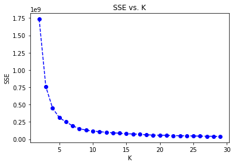

```python
# Investigating change in within-cluster distance across number of clusters.
plt.plot(clusters, scores, linestyle = '--', marker = 'o', color = 'b');
plt.xlabel('K');
plt.ylabel('SSE');
plt.title('SSE vs. K');
```

```python
# Re-fitting the k-means model with the selected number of clusters and obtain
# Cluster Predictions for the general listings data.

from sklearn.cluster import KMeans

k = 10

kmeans = KMeans(k)

model_kmeans = kmeans.fit(listings_df_scaled)
labels_listings = model_kmeans.transform(listings_df_scaled)

listings_kmeans = model_kmeans.predict(listings_df_scaled)
```

### Data Evalution

```python
# adding the cluster column
listings_df_scaled['Cluster'] = pd.Series(listings_kmeans, index = listings_df_scaled.index)
listings_df_scaled.head()
```

|  | host_since | host_listings_count | host_total_listings_count | host_has_profile_pic | host_identity_verified | accommodates | bathrooms | bedrooms | beds | price | ... | room_type_Shared room | bed_type_Couch | bed_type_Futon | bed_type_Pull-out Sofa | bed_type_Real Bed | cancellation_policy_moderate | cancellation_policy_strict_14_with_grace_period | cancellation_policy_super_strict_30 | cancellation_policy_super_strict_60 | Cluster |
| --- | --- | --- | --- | --- | --- | --- | --- | --- | --- | --- | --- | --- | --- | --- | --- | --- | --- | --- | --- | --- | --- |
| 0 | 1.000000 | 0.001486 | 0.001486 | 1 | 0 | 2 | 0.272727 | 0.083333 | 0.06250 | 0.005893 | ... | 0 | 0 | 0 | 0 | 1 | 0 | 1 | 0 | 0 | 8 |
| 1 | 0.921625 | 0.002972 | 0.002972 | 1 | 1 | 2 | 0.272727 | 0.083333 | 0.03125 | 0.012564 | ... | 0 | 0 | 0 | 0 | 1 | 1 | 0 | 0 | 0 | 0 |
| 3 | 0.899164 | 0.002972 | 0.002972 | 1 | 0 | 3 | 0.181818 | 0.083333 | 0.03125 | 0.013231 | ... | 0 | 0 | 0 | 0 | 1 | 0 | 1 | 0 | 0 | 7 |
| 4 | 0.869773 | 0.001486 | 0.001486 | 1 | 1 | 2 | 0.272727 | 0.083333 | 0.03125 | 0.014343 | ... | 0 | 0 | 0 | 0 | 1 | 0 | 1 | 0 | 0 | 4 |
| 8 | 0.840621 | 0.001486 | 0.001486 | 1 | 1 | 3 | 0.181818 | 0.083333 | 0.03125 | 0.019346 | ... | 0 | 0 | 0 | 0 | 1 | 1 | 0 | 0 | 0 | 2 |

5 rows × 208 columns

```python
# Grouping data by Different Clusters
listings_grouped_by_clusters = listings_df_scaled.groupby('Cluster').mean()
listings_grouped_by_clusters.head()
```

| Cluster | host_since | host_listings_count | host_total_listings_count | host_has_profile_pic | host_identity_verified | accommodates | bathrooms | bedrooms | beds | price | ... | room_type_Private room | room_type_Shared room | bed_type_Couch | bed_type_Futon | bed_type_Pull-out Sofa | bed_type_Real Bed | cancellation_policy_moderate | cancellation_policy_strict_14_with_grace_period | cancellation_policy_super_strict_30 | cancellation_policy_super_strict_60 |
| --- | --- | --- | --- | --- | --- | --- | --- | --- | --- | --- | --- | --- | --- | --- | --- | --- | --- | --- | --- | --- | --- |
| 0 | 0.421466 | 0.002630 | 0.002630 | 0.999157 | 0.375053 | 2.887063 | 0.216412 | 0.122875 | 0.054520 | 0.016320 | ... | 0.124737 | 0.001054 | 0.000211 | 0.001475 | 0.003582 | 0.994522 | 0.435946 | 0.405394 | 0.0 | 0.00000 |
| 1 | 0.453308 | 0.002791 | 0.002791 | 0.999184 | 0.421110 | 2.918390 | 0.218741 | 0.127811 | 0.057493 | 0.016365 | ... | 0.136289 | 0.002448 | 0.000544 | 0.002176 | 0.006801 | 0.989663 | 0.406148 | 0.417029 | 0.0 | 0.00136 |
| 2 | 0.429471 | 0.002557 | 0.002557 | 1.000000 | 0.381089 | 2.888252 | 0.229878 | 0.123090 | 0.055516 | 0.017766 | ... | 0.213467 | 0.000000 | 0.000000 | 0.001433 | 0.005731 | 0.991404 | 0.353868 | 0.482808 | 0.0 | 0.00000 |
| 3 | 0.710872 | 0.001486 | 0.001486 | 1.000000 | 1.000000 | 2.000000 | 0.181818 | 0.083333 | 0.031250 | 0.021459 | ... | 0.000000 | 0.000000 | 0.000000 | 0.000000 | 0.000000 | 1.000000 | 0.000000 | 1.000000 | 0.0 | 0.00000 |
| 4 | 0.416452 | 0.004896 | 0.004896 | 0.998280 | 0.388650 | 3.024076 | 0.220589 | 0.116581 | 0.061183 | 0.020088 | ... | 0.424764 | 0.002580 | 0.000000 | 0.000000 | 0.006019 | 0.993121 | 0.319003 | 0.517627 | 0.0 | 0.00000 |

5 rows × 207 columns

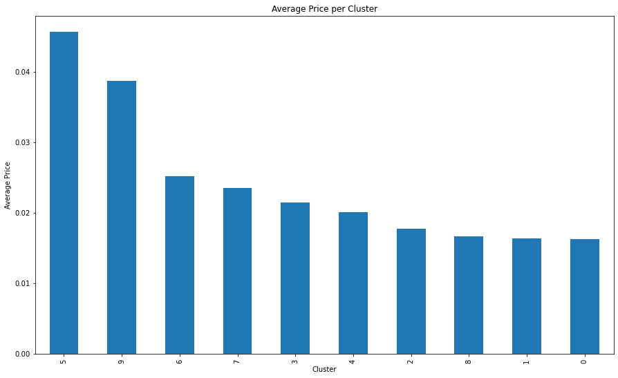

```python
# Price by Clusters formed
avg_price_per_cluster = listings_grouped_by_clusters.price.sort_values(ascending = False)

avg_price_per_cluster.plot.bar(figsize = (15, 9));

plt.title('Average Price per Cluster');
plt.ylabel('Average Price');
```

```python
# Clusters Column mean values
clusters_mean = listings_grouped_by_clusters.mean()
clusters_mean
```

```
host_since                                         0.436936
host_listings_count                                0.008325
host_total_listings_count                          0.008325
host_has_profile_pic                               0.999662
host_identity_verified                             0.405099
                                                     ...
bed_type_Real Bed                                  0.994133
cancellation_policy_moderate                       0.249047
cancellation_policy_strict_14_with_grace_period    0.546447
cancellation_policy_super_strict_30                0.036512
cancellation_policy_super_strict_60                0.031794
Length: 207, dtype: float64
```

```python
# Comparing the different clusters then subtracting the mean
# and the value in each cluster

# Displaying percentage for each cluster and the average mean
clusters_differences_in_mean = ((listings_grouped_by_clusters - clusters_mean) * 100 / clusters_mean)
clusters_differences_in_mean
```

| Cluster | host_since | host_listings_count | host_total_listings_count | host_has_profile_pic | host_identity_verified | accommodates | bathrooms | bedrooms | beds | price | ... | room_type_Private room | room_type_Shared room | bed_type_Couch | bed_type_Futon | bed_type_Pull-out Sofa | bed_type_Real Bed | cancellation_policy_moderate | cancellation_policy_strict_14_with_grace_period | cancellation_policy_super_strict_30 | cancellation_policy_super_strict_60 |
| --- | --- | --- | --- | --- | --- | --- | --- | --- | --- | --- | --- | --- | --- | --- | --- | --- | --- | --- | --- | --- | --- |
| 0 | -3.540579 | -68.409450 | -68.409450 | -0.050512 | -7.416935 | -0.014422 | 0.315925 | 2.941352 | -6.948115 | -32.493849 | ... | -42.336380 | -88.679143 | 8.159101 | -6.588107 | 1.689076 | 0.039082 | 75.046016 | -25.812738 | -100.000000 | -100.000000 |
| 1 | 3.747072 | -66.468213 | -66.468213 | -0.047841 | 3.952453 | 1.070496 | 1.395429 | 7.076269 | -1.873467 | -32.307517 | ... | -36.995705 | -73.691017 | 179.283510 | 37.830823 | 93.071254 | -0.449689 | 63.081155 | -23.683462 | -100.000000 | -95.721972 |
| 2 | -1.708279 | -69.289053 | -69.289053 | 0.033798 | -5.926890 | 0.026768 | 6.557821 | 3.120950 | -5.247902 | -26.513534 | ... | -1.317810 | -100.000000 | -100.000000 | -9.264666 | 62.688809 | -0.274527 | 42.089179 | -11.645945 | -100.000000 | -100.000000 |
| 3 | 62.694971 | -82.151339 | -82.151339 | 0.033798 | 146.853499 | -30.735432 | -15.719706 | -30.185817 | -46.663738 | -11.239324 | ... | -100.000000 | -100.000000 | -100.000000 | -100.000000 | -100.000000 | 0.590144 | -100.000000 | 83.000386 | -100.000000 | -100.000000 |
| 4 | -4.688023 | -41.189968 | -41.189968 | -0.138230 | -4.060377 | 4.730647 | 2.252360 | -2.332179 | 4.425337 | -16.909577 | ... | 96.360969 | -72.280934 | -100.000000 | -100.000000 | 70.872210 | -0.101791 | 28.089541 | -5.274091 | -100.000000 | -100.000000 |
| 5 | -43.145006 | 61.286987 | 61.286987 | 0.033798 | -68.582282 | -14.993485 | -9.590231 | -6.068190 | -5.934230 | 88.676015 | ... | -7.543398 | 681.509660 | -100.000000 | -100.000000 | -100.000000 | 0.590144 | -70.797719 | -56.745363 | 696.759214 | 300.298960 |
| 6 | 10.800288 | 249.288371 | 249.288371 | 0.033798 | -44.457963 | 9.572698 | 2.658080 | 7.048414 | 9.339336 | 4.131552 | ... | -47.351102 | -40.301345 | -100.000000 | 75.925731 | -21.141119 | 0.031310 | -6.309348 | 27.591936 | -92.392056 | -100.000000 |
| 7 | 11.426461 | -26.368950 | -26.368950 | 0.033798 | 14.884087 | 9.930639 | 6.808677 | 14.218670 | 17.492528 | -2.669710 | ... | 16.949878 | -74.353800 | 512.557389 | 202.306745 | 103.263942 | -0.970323 | 9.247197 | 6.786622 | -100.000000 | -66.220937 |
| 8 | 0.743307 | -63.232885 | -63.232885 | 0.033798 | -5.775163 | -0.800903 | 4.486294 | -13.007563 | -1.740137 | -30.867038 | ... | 172.703226 | -32.203421 | -100.000000 | 99.789474 | -10.444173 | -0.044494 | 16.532762 | -5.324721 | -100.000000 | -100.000000 |
| 9 | -36.330212 | 106.534501 | 106.534501 | 0.033798 | -29.470429 | 21.212994 | 0.835351 | 17.188093 | 37.150387 | 60.192982 | ... | -50.469678 | -100.000000 | -100.000000 | -100.000000 | -100.000000 | 0.590144 | -56.978782 | 11.107377 | 95.632843 | 461.643949 |

10 rows × 207 columns